# QBUS2820 - Predictive Analytics

# Tutorial 1 - Part A - Getting Started

Welcome to the first tutorial for QBUS2820!

During the tutorials of QBUS2820 we will focus on practical application of lecture material.

This means you will be coding (programming) in Python.

## Maths and Statistics Review

For QBUS2820 you will need to be familiar with linear algebra, proability and statistics.

If you need any help with this content then please ask.

## Installing Anaconda (Python)

Anaconda and Python are free to download. Please download them from the following link:

https://www.continuum.io/downloads

## Spyder

Spyder is an IDE (Integrated Development Environment) for Python. It allows you to code and run your Python code. It is a lot like MATLAB.

First open Anaconda Navigator then click the “Launch” button for Spyder

[figure not shown]

Spyder will open to the following screen

[figure not shown]

# Python

## Hello World

Python is an interpreted language. This means each piece of code is executed directly without previously compiling the code to a machine-readable format.

In other words, Python can be used interactively!

In the Console at the Console at the bottom right of the Spyder you can type

```python
print("Hello World!")
```

```
Hello World!
```

## Variables

Python stores data in variables.

You may already be familiar with the concept of variables from algebra.

Let’s start by creating a variable called “x” with the value of “10”.

```python
x = 10
```

We can check the value of x by printing it in the console

```python
print(x)
```

```
10
```

**TIP**: You can choose the name of your variables freely, so long as they do not match any existing special keywords or other defined function or library names. Keep your variable names short and meaningful.

Python variables have one major difference from mathematics: variables are not always numeric.

Every variable has a type. The type defines the behavior for the variable.

Python’s numeric data types are:

- int (Integers)
- floats (Floating Point Numbers or Decimals)
- complex (Complex Numbers)

To represent text, we use the string data type. Strings are denoted by wrapping the text in matching single or double quotation marks.

Let’s experiment with some more variables:

```python
y = 5
z = x + y
```

```python
print(z)
```

```
15
```

```python
print( type(z) )
```

```
<class 'int'>
```

Let’s try another example

```python
y = 10.5
z = x + y
```

```python
print(z)
```

```
20.5
```

```python
print( type(z) )
```

```
<class 'float'>
```

Notice that the type of Z is now a float not an integer.

We can do other mathematics operations on numbers:

```python
print(z - 3)
print(z * 5)
print(z / 2)
```

```
17.5
102.5
10.25
```

Note that you can’t mix and match operators between data types. For example it is invalid to add or subtract an integer from a string.

However often data types borrow the concepts of operators from other areas. For example you can join two strings together by using the + operator.

```python
my_string = "Hello World!"
print(my_string)

end_string = " - from Steve"
print(my_string + end_string)
```

```
Hello World!
Hello World! - from Steve
```

**TIP**: You can check the state of variables in your current workspace by using the “Variable Explorer” in Spyder in the top right window pane.

You can define your own data types via Python’s “Class” mechanism, which we will cover later.

## Power of Python

So far we have done very simple tasks in Python. From these very simple foundations you can build very powerful tools. You can combine Python primitives together like Lego blocks to form bigger functional components. These larger functional components can also be combined to form a complete project or solution to your problem!

Fortunately you don't have to start from scratch everytime. The Python community has written libraries (collections of code) to help you complete common tasks. Usually there's a library to help with almost any task! We will cover the use of the essential libraries in QBUS2820.

As an example there is a library called "wordcloud" that we can import and use to create, yes you guessed it, word clouds!

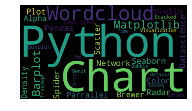

```python
from wordcloud import WordCloud
import matplotlib.pyplot as plt

# Create a list of words
text=("Python Python Python Matplotlib Matplotlib Seaborn Network Plot Violin Chart Pandas Datascience Wordcloud Spider Radar Parrallel Alpha Color Brewer Density Scatter Barplot Barplot Boxplot Violinplot Treemap Stacked Area Chart Chart Visualization Dataviz Donut Pie Time-Series Wordcloud Wordcloud Sankey Bubble")

# Create the wordcloud object
wordcloud = WordCloud(width=1920, height=1080, margin=0).generate(text)

# Display the generated image:
plt.imshow(wordcloud, interpolation='bilinear')
plt.axis("off")
plt.margins(x=0, y=0)
plt.show()
```

## Python Scripts

So far you’ve used the interactive console. The console is great for quick testing and checking variables but for more complex tasks it would be better to store your code so that you can use or run it later.

Let’s create a Python script. A Python script is just a text file that contains Python code, which Python will read and execute line by line.

In Spyder go to File > New File. This will create a new empty Python script in the Script Editor (left pane of Spyder).

In the file add some Python code at the end. For example, the Hello World print function.

Then click the green Run (play icon). The output will be displayed on the console. From now on we will work with Python Scripts.

[figure not shown]

## Lists

Lists are a way to store an ordered collection of variables or objects. Let’s create a list and store it in the variable my_list.

```python
my_list = [1, 2, 4, 8, 16]
print(my_list)
```

```
[1, 2, 4, 8, 16]
```

List items can be accessed by their index. Python uses zero-indexing which means the first item starts at 0.

Print the value of the first item:

```python
print(my_list[0])
```

```
1
```

To add items to the list you can use the append function

```python
my_list.append(32)
```

To find out how many items are in the list use the len function

```python
print(len(my_list))
```

```
6
```

To create an empty list, you can use the list constructor function then append items later

```python
my_new_list = list()

my_new_list.append(10)
my_new_list.append(12)

print(my_new_list)
```

```
[10, 12]
```

## User Input

The code we have used so far always does the same thing. Useful real code acts on input data. One way to get this data is directly from the user.

Let’s capture the user’s name and display a welcome message:

```python
# Python 3
name = input("Enter your name:")

print("Welcome " + name)
```

```
Enter your name:steve
Welcome steve
```

The type of variable name is a string.

### Python 2.7

In Python 2.7 input returns an integer automatically. To read a string you will need to use raw_input like so

```python
# Python 2.7
name = raw_input("Enter your name:")

print("Welcome " + name)
```

## Comments

As your program gets more complicated you may want to add some notes to your code to help you remember what your code does or to explain to others who are using your code later.

In Python everything to the right hand side of a # symbol is considered a comment and is ignored by Python.

**TIP**: Comments can also be used to quickly disable specific lines of code.

Multi line comments can be created by wrapping your comment in a pair of triple quotation marks like so

```python
"""
This is
a
multi line
comment
"""
```

## Conditionals

So far when we press Run the code has been executed line by line. But what about if we want to execute a different piece of code based on the current state or value of a variable?

This is where the conditional statements if, elif and else come into play. These statements allow us to branch the execution path.

```python
# Accept input, then convert input string to integer
input_number = int(input("Enter a number:"))

if input_number > 3:
    print("number is greater than 3")
elif input_number == 3:
    print("number is equal to 3")
else:
    print("number is less than 3")
```

```
Enter a number:9
number is greater than 3
```

**Tip**: The input function waits to the user to enter a string that ends in a return or new line character. The int function converts the input string to an integer.

## Loops

A fundamental component of computer programming is iteration. In other words the ability to do repeated tasks.

In Python we do this using loops. There are two types of loops: • For loop • While loop

Let’s start with an example of the For loop by iterating over our list of numbers that we created earlier and printing their values

```python
for number in my_list:
    print(number)
```

You can also use list indexing to do the same thing. Try this

```python
for i in range(len(my_list)):
    print(my_list[i])
```

While loops are a little more complicated. They continue iterating until a conditional statement becomes false. Try the following

```python
count = 0
while (count < len(my_list)):
    print(my_list[count])
    count = count + 1
```

Tip: Be careful with loops (particularly while loops) as you may accidentally create an infinite loop which Python can’t escape from. You will need to quit Spyder to stop an infinite loop.

## Functions

Functions in Python (and other programming languages) are based on functions from mathematics. They encapsulate a piece of repeated functionality and they allow optional input and produce optional output.

Functions are a great way to divide your code into reusable building blocks, which makes your code more readable and may save you time and effort.

Try this example

```python
def add(a, b):
    return a + b

c = add(10, 5)
print(c)
```

The function called “add” has a two parameters which we called “a” and “b”. Inside the function Python will replace each occurrence of the parameters with the values that we specified.

**TIP**: def keyword means “define”

## String Formatting

A common task you may encounter is outputting strings that are nicely formatted. You can use the format function of string objects to help you.

The format function scans the input string for curly braces “{ }”. Each curly brace has a number. This number is an index into the parameter list of the format function. In this example {0} corresponds to “name” and {1} corresponds to age.

```python
year = int(input("Enter your birth year: "))

age = 2017 - year

fancy_string = "Hi {0}, you are {1} years old".format(name, age)

print(fancy_string)
```

**TIPS**:

- The . (dot) syntax calls a function belonging to that object. In this example we are calling the “format” function belonging to the string object.
- The format function replaces occurrences of numbered curly braces with corresponding parameter values.

## Classes and Objects

An object is a container that represents a “thing”. Inside the container there are:

- Functions
- Attributes

Imagine we want to represent a person in our program. We might define a “person” class. People have attributes like age, height, weight, name etc. They also “do” things, in other words they have functionality. Some function examples might be: eat, sleep, walk and study.

Lets look at a more practical example: a customer’s bank account. We need to keep track of the balance and which customer it belongs to. We also need to be able to withdraw and deposit money.

```python
class Customer(object):
    #A bank customer

    def __init__(self, name, balance):
        self.name = name
        self.balance = balance

    def __str__(self):
        return "Account for {0}, balance of {1}".format(self.name, self.balance)

    def widthdraw(self, amount):
        self.balance = self.balance - amount
        return self.balance

    def deposit(self, amount):
        self.balance = self.balance + amount
        return self.balance
```

**TIP**: The functions that start and end with double underscores (__) are special functions in Python. The __init__ function (initialize) is called the class constructor. It gets called when you create the object. The __str__ function (string) is called when printing the object.

Create an instance of the customer class by calling the constructor and specifying a name (use your own name) and starting balance

```python
new_customer = Customer("Steve", 1000.00)
```

You can then access the attributes of the object by using the dot notation.

```python
print(new_customer.balance)
print(new_customer.name)
```

We have also explicitly define the string function so you can try

```python
print(new_customer)
```

Accessing the functions of an object is much the same

```python
new_customer.widthdraw(100)

print(new_customer.balance)
```

More info at https://docs.python.org/3/tutorial/classes.html